# AUS CPI graphs FiveThirtyEight style - final

## Australian CPI graphs in FiveThirtyEight style

Website FiveThirtyEight has been known for publishing attractive graphs. Their aesthetic style could now be reproduced with Python's matplotlib package via the style feature. I will attempt to create a time series for the Australian CPI index using the matplotlib library and the data from the Australian Bureau of Statistics. The original Excel workbook came with a spreadsheet for the CPIs according to the major cities, and another spreadsheet organised by the consumption category. The two spreadsheets were saved into two separate csv files.

The files could be found at http://www.abs.gov.au/AUSSTATS/abs@.nsf/DetailsPage/6401.0Dec%202017?OpenDocument

It has been known that housing affordability has worsen while the general rate of inflation has been subdued. The economic trend is not even across Australia as some cities such as Melbourne and Sydney are known to have higher standards of living which is reflected by their higher cost of living. This CPI graph will enable us to identify the different trends across the major cities and the different consumption categories.

```python
#read the csv files with Pandas.
import pandas as pd
import copy
import matplotlib
%matplotlib inline

aus_cpi_types = pd.read_csv('aus_cpi_types.csv')
aus_cpi_cities = pd.read_csv('aus_cpi_cities.csv')
```

Examine the datasets. We will focus on the CPI types data and apply the same process onto the Cities data.

```python
print(aus_cpi_types.info())
aus_cpi_types.head()
```

```
<class 'pandas.core.frame.DataFrame'>
RangeIndex: 34 entries, 0 to 33
Data columns (total 13 columns):
Period                                           34 non-null object
Food and non-alcoholic beverages                 34 non-null float64
Alcohol and tobacco                              34 non-null float64
Clothing and footwear                            34 non-null float64
Housing                                          34 non-null float64
Furnishings, household equipment and services    34 non-null float64
Health                                           34 non-null float64
Transport                                        34 non-null float64
Communication                                    34 non-null float64
Recreation and culture                           34 non-null float64
Education                                        34 non-null float64
Insurance and financial services                 34 non-null float64
All groups(b)                                    34 non-null float64
dtypes: float64(12), object(1)
memory usage: 3.5+ KB
None
```

|  | Period | Food and non-alcoholic beverages | Alcohol and tobacco | Clothing and footwear | Housing | Furnishings, household equipment and services | Health | Transport | Communication | Recreation and culture | Education | Insurance and financial services | All groups(b) |
| --- | --- | --- | --- | --- | --- | --- | --- | --- | --- | --- | --- | --- | --- |
| 0 | 1/09/2005 | 0.8 | 1.0 | 0.1 | 1.4 | 0.3 | -1.1 | 3.3 | -0.7 | 1.3 | 0.1 | 0.1 | 1.0 |
| 1 | 1/12/2005 | 1.9 | 0.5 | -0.1 | 0.7 | 0.6 | -1.1 | -0.5 | -0.7 | 0.0 | 0.0 | 1.5 | 0.5 |
| 2 | 1/03/2006 | 1.4 | 1.2 | -2.6 | 0.7 | -0.3 | 4.4 | 1.3 | 0.4 | 0.6 | 5.7 | -0.6 | 0.8 |
| 3 | 1/06/2006 | 4.1 | 0.9 | 0.9 | 0.8 | 0.7 | 2.3 | 3.4 | 0.1 | -0.3 | 0.0 | 1.2 | 1.7 |
| 4 | 1/09/2006 | 2.3 | 0.5 | 0.1 | 1.2 | 1.4 | -0.8 | 0.4 | 0.6 | 0.7 | -0.9 | 0.3 | 0.9 |

The data currently has the CPI changes per quarter in terms of percentages. A more accurate measure would be to set a baseline of 100 as the first row and calculate a cumulative sum for each column to find the CPI index realtive to the baseline at 01/06/2005.

This would require a row to be added and the cumulative sum calculated.

```python
#Add a new row on top called with 1/06/2005 as the period
#Followed by a value of 100 across all the other columns.
temp=[]
temp.insert(0, {'Period':'1/06/2005'})
#add the row onto the aus_cpi_types and aus_cities dataframe
temp2=pd.concat([pd.DataFrame(temp), aus_cpi_types], ignore_index=True)
temp3=pd.concat([pd.DataFrame(temp), aus_cpi_cities], ignore_index=True)
```

```python
#create a copy
types_copy=copy.copy(aus_cpi_types)
#create a copy
cities_copy=copy.copy(aus_cpi_cities)
```

```python
temp2.head()
```

|  | Alcohol and tobacco | All groups(b) | Clothing and footwear | Communication | Education | Food and non-alcoholic beverages | Furnishings, household equipment and services | Health | Housing | Insurance and financial services | Period | Recreation and culture | Transport |
| --- | --- | --- | --- | --- | --- | --- | --- | --- | --- | --- | --- | --- | --- |
| 0 | NaN | NaN | NaN | NaN | NaN | NaN | NaN | NaN | NaN | NaN | 1/06/2005 | NaN | NaN |
| 1 | 1.0 | 1.0 | 0.1 | -0.7 | 0.1 | 0.8 | 0.3 | -1.1 | 1.4 | 0.1 | 1/09/2005 | 1.3 | 3.3 |
| 2 | 0.5 | 0.5 | -0.1 | -0.7 | 0.0 | 1.9 | 0.6 | -1.1 | 0.7 | 1.5 | 1/12/2005 | 0.0 | -0.5 |
| 3 | 1.2 | 0.8 | -2.6 | 0.4 | 5.7 | 1.4 | -0.3 | 4.4 | 0.7 | -0.6 | 1/03/2006 | 0.6 | 1.3 |
| 4 | 0.9 | 1.7 | 0.9 | 0.1 | 0.0 | 4.1 | 0.7 | 2.3 | 0.8 | 1.2 | 1/06/2006 | -0.3 | 3.4 |

```python
temp3.head()
```

|  | Adelaide | Brisbane | Canberra | Darwin | Hobart | Melbourne | Period | Perth | Sydney | Weighted average of eight capital cities |
| --- | --- | --- | --- | --- | --- | --- | --- | --- | --- | --- |
| 0 | NaN | NaN | NaN | NaN | NaN | NaN | 1/06/2005 | NaN | NaN | NaN |
| 1 | 0.8 | 0.9 | 0.8 | 1.1 | 0.2 | 0.8 | 1/09/2007 | 0.7 | 0.5 | 0.7 |
| 2 | 1.0 | 1.0 | 0.9 | 0.3 | 0.9 | 1.0 | 1/12/2007 | 0.8 | 0.9 | 0.9 |
| 3 | 1.3 | 1.4 | 1.5 | 0.9 | 1.2 | 1.3 | 1/03/2008 | 1.3 | 1.3 | 1.3 |
| 4 | 1.3 | 1.7 | 1.2 | 1.5 | 1.1 | 1.2 | 1/06/2008 | 1.7 | 1.6 | 1.4 |

```python
#Reorder the columns for both datasets by their original order
arraytypes=aus_cpi_types.columns.values
arraycities=aus_cpi_cities.columns.values
aus_cpi_types=temp2[arraytypes]
aus_cpi_cities=temp3[arraycities]
```

```python
aus_cpi_types.head()
```

|  | Period | Food and non-alcoholic beverages | Alcohol and tobacco | Clothing and footwear | Housing | Furnishings, household equipment and services | Health | Transport | Communication | Recreation and culture | Education | Insurance and financial services | All groups(b) |
| --- | --- | --- | --- | --- | --- | --- | --- | --- | --- | --- | --- | --- | --- |
| 0 | 1/06/2005 | NaN | NaN | NaN | NaN | NaN | NaN | NaN | NaN | NaN | NaN | NaN | NaN |
| 1 | 1/09/2005 | 0.8 | 1.0 | 0.1 | 1.4 | 0.3 | -1.1 | 3.3 | -0.7 | 1.3 | 0.1 | 0.1 | 1.0 |
| 2 | 1/12/2005 | 1.9 | 0.5 | -0.1 | 0.7 | 0.6 | -1.1 | -0.5 | -0.7 | 0.0 | 0.0 | 1.5 | 0.5 |
| 3 | 1/03/2006 | 1.4 | 1.2 | -2.6 | 0.7 | -0.3 | 4.4 | 1.3 | 0.4 | 0.6 | 5.7 | -0.6 | 0.8 |
| 4 | 1/06/2006 | 4.1 | 0.9 | 0.9 | 0.8 | 0.7 | 2.3 | 3.4 | 0.1 | -0.3 | 0.0 | 1.2 | 1.7 |

```python
#Add a baseline value of 100 on the first row of all columns as a reference point for CPI.
aus_cpi_types.iloc[0,1:]=100
aus_cpi_cities.iloc[0,1:]=100
```

```python
aus_cpi_types.head()
```

|  | Period | Food and non-alcoholic beverages | Alcohol and tobacco | Clothing and footwear | Housing | Furnishings, household equipment and services | Health | Transport | Communication | Recreation and culture | Education | Insurance and financial services | All groups(b) |
| --- | --- | --- | --- | --- | --- | --- | --- | --- | --- | --- | --- | --- | --- |
| 0 | 1/06/2005 | 100.0 | 100.0 | 100.0 | 100.0 | 100.0 | 100.0 | 100.0 | 100.0 | 100.0 | 100.0 | 100.0 | 100.0 |
| 1 | 1/09/2005 | 0.8 | 1.0 | 0.1 | 1.4 | 0.3 | -1.1 | 3.3 | -0.7 | 1.3 | 0.1 | 0.1 | 1.0 |
| 2 | 1/12/2005 | 1.9 | 0.5 | -0.1 | 0.7 | 0.6 | -1.1 | -0.5 | -0.7 | 0.0 | 0.0 | 1.5 | 0.5 |
| 3 | 1/03/2006 | 1.4 | 1.2 | -2.6 | 0.7 | -0.3 | 4.4 | 1.3 | 0.4 | 0.6 | 5.7 | -0.6 | 0.8 |
| 4 | 1/06/2006 | 4.1 | 0.9 | 0.9 | 0.8 | 0.7 | 2.3 | 3.4 | 0.1 | -0.3 | 0.0 | 1.2 | 1.7 |

```python
#Calculate the cumulative sum of all values
aus_cpi_types.iloc[:, 1:]=aus_cpi_types.iloc[:, 1:].cumsum(axis=0)
aus_cpi_cities.iloc[:, 1:]=aus_cpi_cities.iloc[:, 1:].cumsum(axis=0)
```

```python
aus_cpi_types.head()
```

|  | Period | Food and non-alcoholic beverages | Alcohol and tobacco | Clothing and footwear | Housing | Furnishings, household equipment and services | Health | Transport | Communication | Recreation and culture | Education | Insurance and financial services | All groups(b) |
| --- | --- | --- | --- | --- | --- | --- | --- | --- | --- | --- | --- | --- | --- |
| 0 | 1/06/2005 | 100.0 | 100.0 | 100.0 | 100.0 | 100.0 | 100.0 | 100.0 | 100.0 | 100.0 | 100.0 | 100.0 | 100.0 |
| 1 | 1/09/2005 | 100.8 | 101.0 | 100.1 | 101.4 | 100.3 | 98.9 | 103.3 | 99.3 | 101.3 | 100.1 | 100.1 | 101.0 |
| 2 | 1/12/2005 | 102.7 | 101.5 | 100.0 | 102.1 | 100.9 | 97.8 | 102.8 | 98.6 | 101.3 | 100.1 | 101.6 | 101.5 |
| 3 | 1/03/2006 | 104.1 | 102.7 | 97.4 | 102.8 | 100.6 | 102.2 | 104.1 | 99.0 | 101.9 | 105.8 | 101.0 | 102.3 |
| 4 | 1/06/2006 | 108.2 | 103.6 | 98.3 | 103.6 | 101.3 | 104.5 | 107.5 | 99.1 | 101.6 | 105.8 | 102.2 | 104.0 |

In order to graph the time series in chronological order, the period column needs to be converted from a string into a date format.

```python
#Period is currently a string(object) and needs to be converted into datetime format.
import datetime
aus_cpi_types['Period']=pd.to_datetime(aus_cpi_types['Period'],format='%d/%m/%Y')
aus_cpi_types.dtypes
aus_cpi_cities['Period']=pd.to_datetime(aus_cpi_types['Period'],format='%d/%m/%Y')
#Rename the weighted average column in cities.
aus_cpi_cities=aus_cpi_cities.rename(columns={'Weighted average of eight capital cities':'National weighted average'})
```

```python
#create arrays of column names for graphing
cpitypes=aus_cpi_types.columns.values[1:]
cpicities=aus_cpi_cities.columns.values[1:]
print(cpitypes)
print(cpicities)
```

```
['Food and non-alcoholic beverages' 'Alcohol and tobacco'
 'Clothing and footwear' 'Housing'
 'Furnishings, household equipment and services' 'Health' 'Transport'
 'Communication' 'Recreation and culture' 'Education'
 'Insurance and financial services' 'All groups(b)']
['Sydney' 'Melbourne' 'Brisbane' 'Adelaide ' 'Perth' 'Hobart' 'Darwin'
 'Canberra' 'National weighted average']
```

Testing the plots

```
Type: <class 'matplotlib.axes._subplots.AxesSubplot'>
```

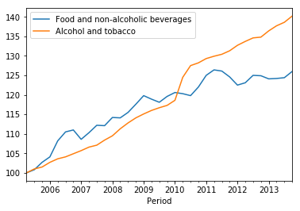

```python
#create a plot of just the first two columns
aus_cpi_types_graph = aus_cpi_types.plot(x = 'Period', y = cpitypes[0:2], figsize = (6,4))
print('Type:', type(aus_cpi_types_graph))
```

```
Type: <class 'matplotlib.axes._subplots.AxesSubplot'>
```

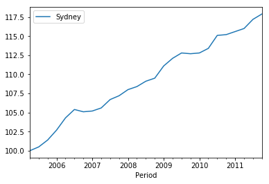

```python
#create a plot of just the first column
aus_cpi_cities_graph = aus_cpi_cities.plot(x = 'Period', y = cpicities[0:1], figsize = (6,4))
print('Type:', type(aus_cpi_cities_graph))
```

```python
#import the five thirty eight style
import matplotlib.style as style
style.use('fivethirtyeight')
```

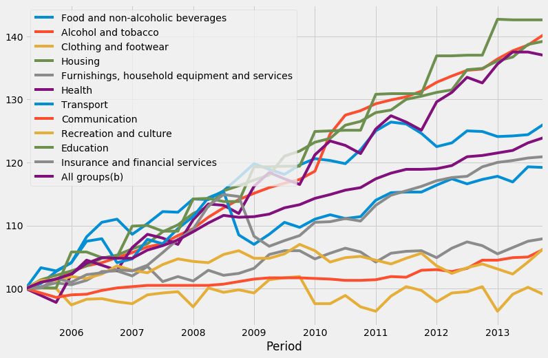

```python
aus_cpi_types.plot(x = 'Period', y = cpitypes, figsize = (12,8))
```

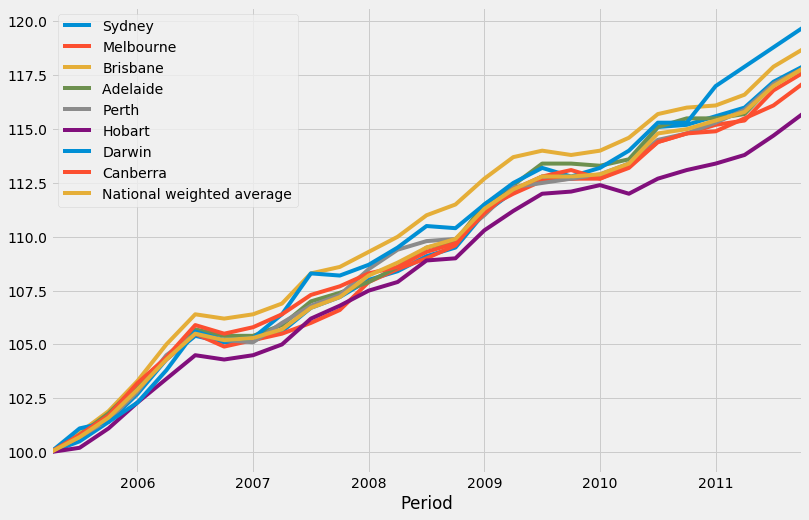

```python
aus_cpi_cities.plot(x = 'Period', y = cpicities, figsize = (12,8))
```

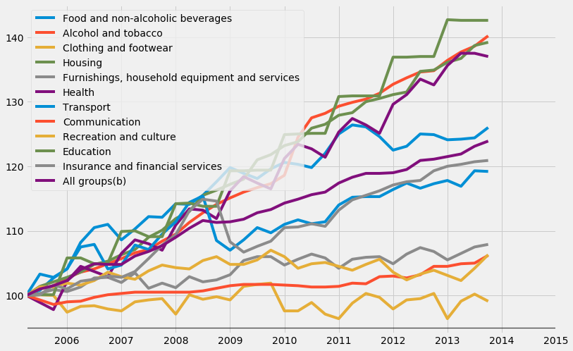

```python
#expand the graph's x axis on the right to make room for labels
import datetime
aus_cpi_types_graph = aus_cpi_types.plot(x = 'Period', y = cpitypes, figsize = (12,8))
aus_cpi_types_graph.axhline(y = 95, color = 'black', linewidth = 1.3, alpha = .7)
aus_cpi_types_graph.set_xlim(right = datetime.date(2015, 1, 1))
aus_cpi_types_graph.xaxis.label.set_visible(False)
```

```python
aus_cpi_types.shape
```

```
(35, 13)
```

```python
cpitypes
```

```
array(['Food and non-alcoholic beverages', 'Alcohol and tobacco',
       'Clothing and footwear', 'Housing',
       'Furnishings, household equipment and services', 'Health',
       'Transport', 'Communication', 'Recreation and culture', 'Education',
       'Insurance and financial services', 'All groups(b)'], dtype=object)
```

Due to some colours being repeated under the default setting, a new set of distinctive colours should be generated for each of the lines. The colour package could generate a series of colour objects and the number of colours should correspond to the number of columns. These colour values could be used for the text labels.

```python
#create a colour list of 12 values that ranges from red to purple
from colour import Color
red = Color("red")
blue = Color("purple")
newlist=list(red.range_to(blue, 12))
```

After generating the colour specifications from the colour package, the colour values are currently colour objects, which are unreadable by matplotlib. So, the they will need to be converted by selecting the hex attribute of each value.